# NZ Floral Volatilome Analysis

Author

Tom Moore & Flore Mas

Published

March 4, 2026

# Overview

This report analyses floral volatile organic compounds (VOCs) from New Zealand plants. We use a cleaned dataset of compounds by sample, with plant species classified as **Natives**, **Crops**, or **Ornamentals**. The analysis covers: (1) chemical class distribution across categories, (2) diversity metrics (richness, Shannon/Hill, evenness) and their comparison by category, (3) overlap of compounds between categories (Venn), (4) seasonal phenology of VOC composition, and (5) supplementary ordination (NMDS), dispersion, and phylogeny. Statistical tests include chi-square (class vs category), ANOVA and post-hoc Wilcoxon (diversity), and Kruskal–Wallis (phenology); test outputs are in collapsible sections so you can show or hide them.

Although AI was used to format the analysis and this Quarto document, all decisions about what types of analysis to perform and what types of plots to use were made by the authors.

**Dataframe (click to show/hide)**

## Dataframe

**Dataframe structure** (`str(df)`):

```
tibble [4,942 × 20] (S3: tbl_df/tbl/data.frame)
 $ compound     : Factor w/ 454 levels "(-)-Aristolene",..: 44 44 44 44 44 44 44 257 257 257 ...
 $ unique_id    : Factor w/ 428 levels "01 nov s6f-Haw",..: 363 387 364 178 179 388 389 193 195 196 ...
 $ plant        : Factor w/ 113 levels "Abutilon sp",..: 88 15 88 55 55 15 15 67 7 7 ...
 $ type         : Factor w/ 3 levels "Arable","Flower",..: 1 2 1 2 2 2 2 2 2 2 ...
 $ new_cat      : Factor w/ 3 levels "Crops","Natives",..: 1 3 1 3 3 3 3 3 3 3 ...
 $ genus        : Factor w/ 89 levels "Abutilon","Actaea",..: 75 13 75 50 50 13 13 62 6 6 ...
 $ family       : Factor w/ 42 levels "Actinidiaceae",..: 9 11 9 20 20 11 11 27 7 7 ...
 $ order        : Factor w/ 23 levels "Apiales","Asparagales",..: 5 9 5 14 14 9 9 18 3 3 ...
 $ location     : Factor w/ 13 levels "Aotearoa","Bay of plenty",..: 4 7 4 8 8 7 7 8 8 8 ...
 $ region       : Factor w/ 5 levels "Aotearoa","Central north island",..: 5 5 5 4 4 5 5 4 4 4 ...
 $ new_class    : Factor w/ 4 levels "Fatty acid derivatives",..: 1 1 1 1 1 1 1 1 1 1 ...
 $ new_sub_class: Factor w/ 15 levels "Hydrocarbons",..: 4 4 4 4 4 4 4 1 1 1 ...
 $ sum_area     : num [1:4942] 2073 1686 998 114 2617 ...
 $ perc_area    : num [1:4942] NA NA NA NA NA NA NA NA NA NA ...
 $ prop_area    : num [1:4942] NA NA NA NA NA NA NA NA NA NA ...
 $ smiles       : Factor w/ 239 levels "C/c(=c\\ccc(c)(c=c)o)/co",..: 80 80 80 80 80 80 80 151 151 151 ...
 $ inchikeys    : Factor w/ 239 levels "Adidqizbyuabqk-rwmbfglxsa-n",..: 136 136 136 136 136 136 136 139 139 139 ...
 $ abundance    : num [1:4942] 2073 1686 998 114 2617 ...
 $ sum_abund    : num [1:4942] 2073 4208 998 7249 9148 ...
 $ rel_abund    : num [1:4942] 1 0.4007 1 0.0157 0.2861 ...
```

**Descriptive statistics (click to show/hide)**

## Descriptive statistics

Summaries by sample, plant, category, and chemical class (shown below).

| unique_id | unique_id_compound | total_voc |
| --- | --- | --- |
| 01 nov s6f-Haw | 7 | 17972 |
| 20 oct a1 c-Haw | 1 | 3671 |
| 20 oct a2 l-Haw | 2 | 3537 |
| 20 oct a3 f-Haw | 8 | 20426 |
| 20 oct a4 l-Haw | 5 | 11766 |
| 20 oct a5 f-Haw | 10 | 17945 |
| 20 oct a6 f-Haw | 7 | 13197 |
| Akeake-f-pooled-Aot | 21 | 33830 |
| Akeake-f1-Aot | 23 | 32239 |
| Akeake-f2-Aot | 22 | 36179 |

| plant | type | count_compound | n_replicates | mean_total_voc |
| --- | --- | --- | --- | --- |
| Abutilon sp | Ornamentals | 9 | 3 | 14250.667 |
| Actaea racemosa | Ornamentals | 7 | 3 | 12940.000 |
| Actinidia chinensis | Crops | 36 | 3 | 125248.932 |
| Actinidia deliciosa | Crops | 43 | 6 | 168924.529 |
| Alseuosmia quercifolia | Natives | 10 | 4 | 20347.378 |
| Aristotelia serrata | Natives | 4 | 4 | 3078.182 |
| Artemisia dracunculus | Ornamentals | 8 | 3 | 13461.667 |
| Borago pygmaea | Ornamentals | 1 | 3 | 2326.667 |
| Brachyglottis repanda | Natives | 28 | 4 | 46586.012 |
| Brassica oleracea | Crops | 21 | 2 | 30324.643 |

[output cut: 103 more lines]

| new_cat | nb_plant | mean_comp | median_voc | min_comp | max_comp | mean_total_voc | min_total_voc | max_total_voc |
| --- | --- | --- | --- | --- | --- | --- | --- | --- |
| Crops | 13 | 44.13587 | 43 | 4 | 59 | 91554.87 | 91554.87 | 91554.87 |
| Natives | 34 | 20.99297 | 19 | 1 | 38 | 31443.83 | 31443.83 | 31443.83 |
| Ornamentals | 66 | 30.89896 | 20 | 1 | 81 | 47486.63 | 47486.63 | 47486.63 |

| new_class | count | percent |
| --- | --- | --- |
| Fatty acid derivatives | 1149 | 23.24970 |
| Terpenoids | 2611 | 52.83286 |
| Benzenoid | 644 | 13.03116 |
| NA | 538 | 10.88628 |

# Figures & hypothesis tests

## Figure 1

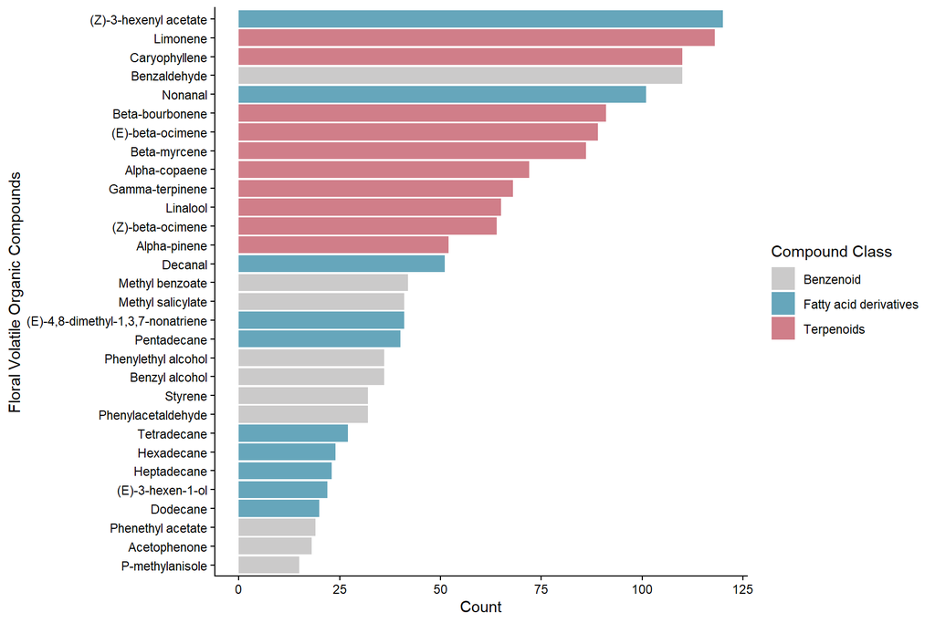

## Figure 2

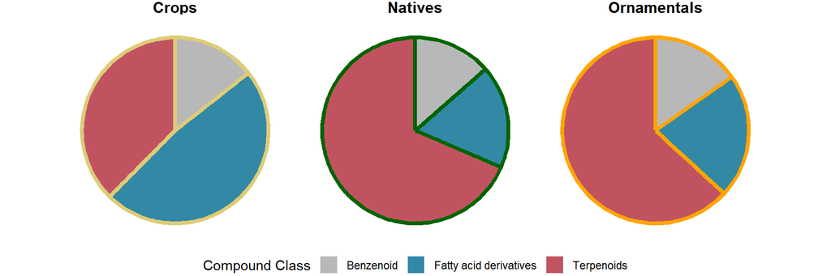

**Chi-square test (chemical class vs category)**

```
    Pearson's Chi-squared test

data:  contingency_table
X-squared = 308.84, df = 4, p-value < 2.2e-16
```

## Figure 3

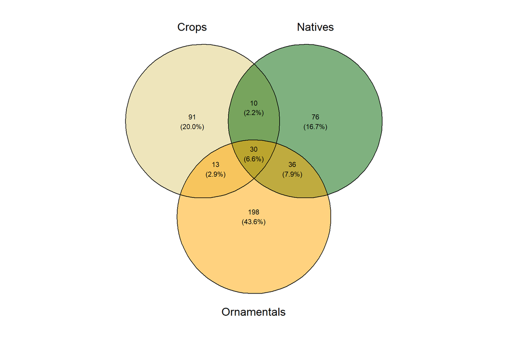

## Figure 4

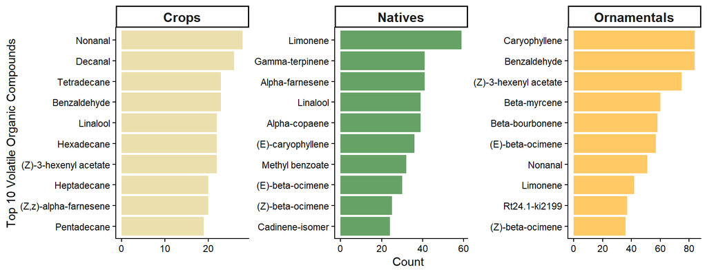

## Figure 5

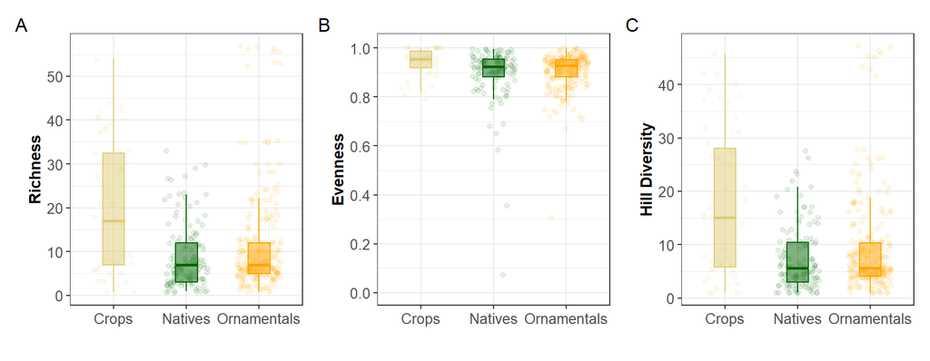

**Figure 5: Kruskal–Wallis and post-hoc Wilcoxon (diversity by category)**

```
    Kruskal-Wallis rank sum test

data:  richness by new_cat
Kruskal-Wallis chi-squared = 23.218, df = 2, p-value = 9.086e-06
```

```
    Kruskal-Wallis rank sum test

data:  hill_q1 by new_cat
Kruskal-Wallis chi-squared = 23.165, df = 2, p-value = 9.329e-06
```

```
    Kruskal-Wallis rank sum test

data:  evenness by new_cat
Kruskal-Wallis chi-squared = 14.547, df = 2, p-value = 0.0006937
```

```
    Pairwise comparisons using Wilcoxon rank sum test with continuity correction

data:  diversity_df$richness and diversity_df$new_cat

            Crops   Natives
Natives     1.1e-05 -
Ornamentals 0.00014 0.04510

P value adjustment method: BH
```

```
    Pairwise comparisons using Wilcoxon rank sum test with continuity correction

data:  diversity_df$hill_q1 and diversity_df$new_cat

            Crops   Natives
Natives     8.5e-06 -
Ornamentals 9.4e-05 0.079

P value adjustment method: BH
```

```
    Pairwise comparisons using Wilcoxon rank sum test with continuity correction

data:  diversity_df$evenness and diversity_df$new_cat

            Crops   Natives
Natives     0.00191 -
Ornamentals 0.00043 0.81107

P value adjustment method: BH
```

**Figure 5: Disparity analysis (mean distance by category)**

```
                Crops   Natives Ornamentals
Crops       0.8710678 0.9616976   0.9607718
Natives     0.9616976 0.9183365   0.9722222
Ornamentals 0.9607718 0.9722222   0.9425781
attr(,"class")
[1] "meandist" "matrix"
attr(,"n")
grouping
      Crops     Natives Ornamentals
         51         129         248
```

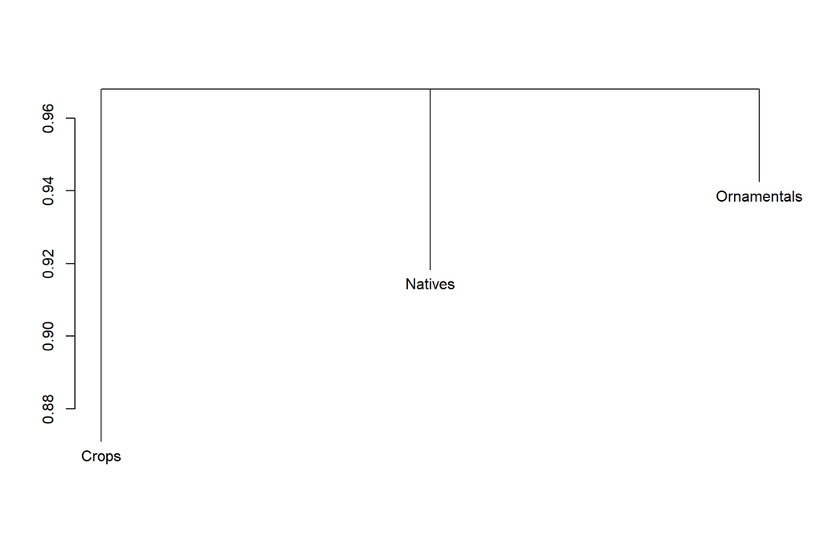

## Figure 6

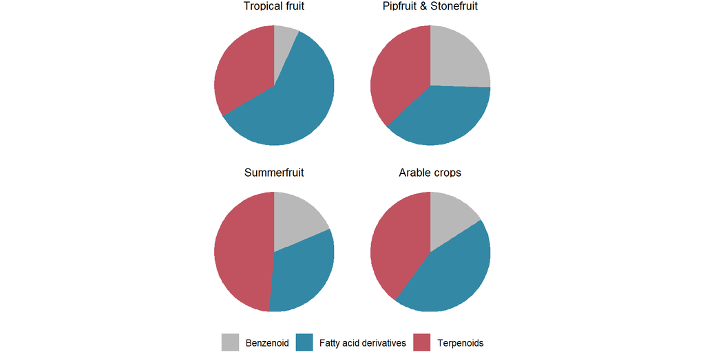

## Figure 7

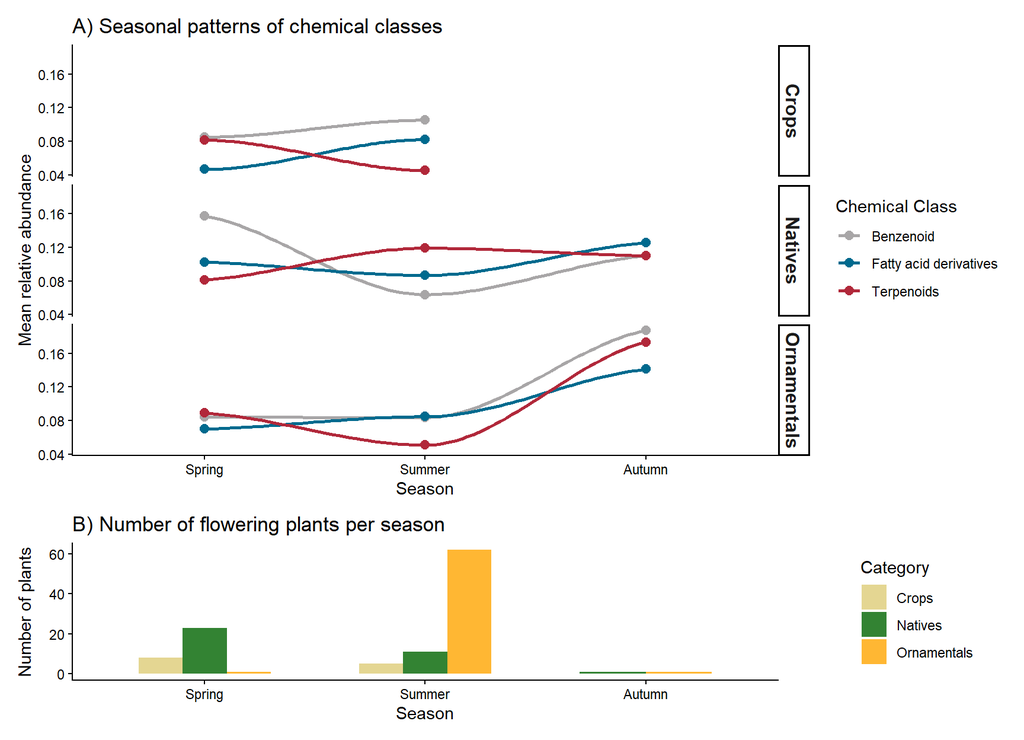

**Figure 7: Kruskal–Wallis and post-hoc Wilcoxon (phenology by category × class)**

```
Crops - Benzenoid : Kruskal-Wallis p = 0.004

    Pairwise comparisons using Wilcoxon rank sum test with continuity correction

data:  class_data$rel_abund and class_data$season

       Spring
Summer 0.004

P value adjustment method: BH
Crops - Fatty acid derivatives : Kruskal-Wallis p = 0.00357

    Pairwise comparisons using Wilcoxon rank sum test with continuity correction

data:  class_data$rel_abund and class_data$season

       Spring
Summer 0.0036

P value adjustment method: BH
Crops - Terpenoids : Kruskal-Wallis p = 0.106
Natives - Benzenoid : Kruskal-Wallis p = 6.58e-08

    Pairwise comparisons using Wilcoxon rank sum test with continuity correction

data:  class_data$rel_abund and class_data$season

       Spring  Summer
Summer 5.5e-08 -
Autumn 0.82490 0.00056

P value adjustment method: BH
Natives - Fatty acid derivatives : Kruskal-Wallis p = 0.000375

    Pairwise comparisons using Wilcoxon rank sum test with continuity correction

data:  class_data$rel_abund and class_data$season

       Spring Summer
Summer 0.1447 -
```

[output cut: 22 more lines]

```
Autumn 0.0001 1.5e-07

P value adjustment method: BH
Ornamentals - Fatty acid derivatives : Kruskal-Wallis p = 0.000648

    Pairwise comparisons using Wilcoxon rank sum test with continuity correction

data:  class_data$rel_abund and class_data$season

       Spring Summer
Summer 0.0323 -
Autumn 0.0323 0.0041

P value adjustment method: BH
Ornamentals - Terpenoids : Kruskal-Wallis p = <2e-16
```

```
    Pairwise comparisons using Wilcoxon rank sum test with continuity correction

data:  class_data$rel_abund and class_data$season

       Spring  Summer
Summer 9.9e-07 -
Autumn 0.0052  < 2e-16

P value adjustment method: BH
```

# Supplementary material

### ESM1

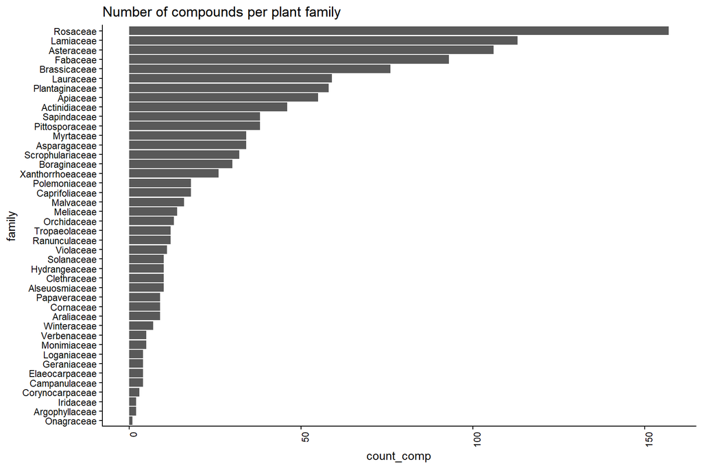

### ESM2

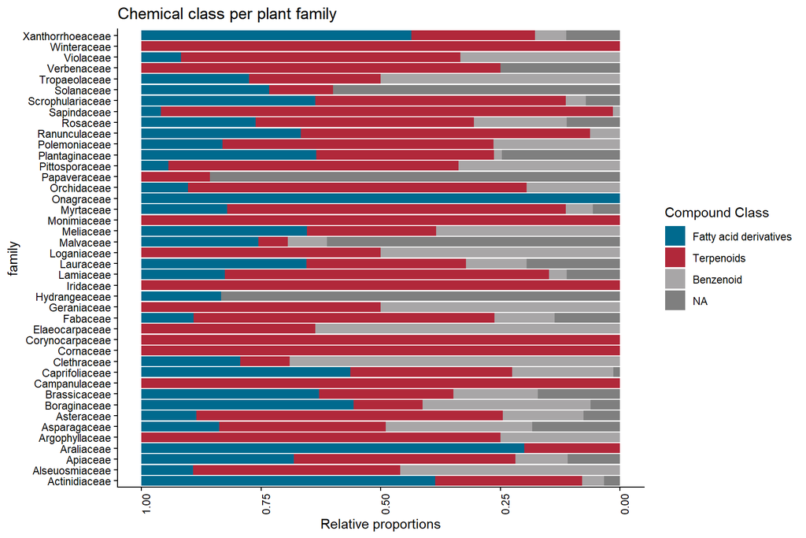

### ESM3

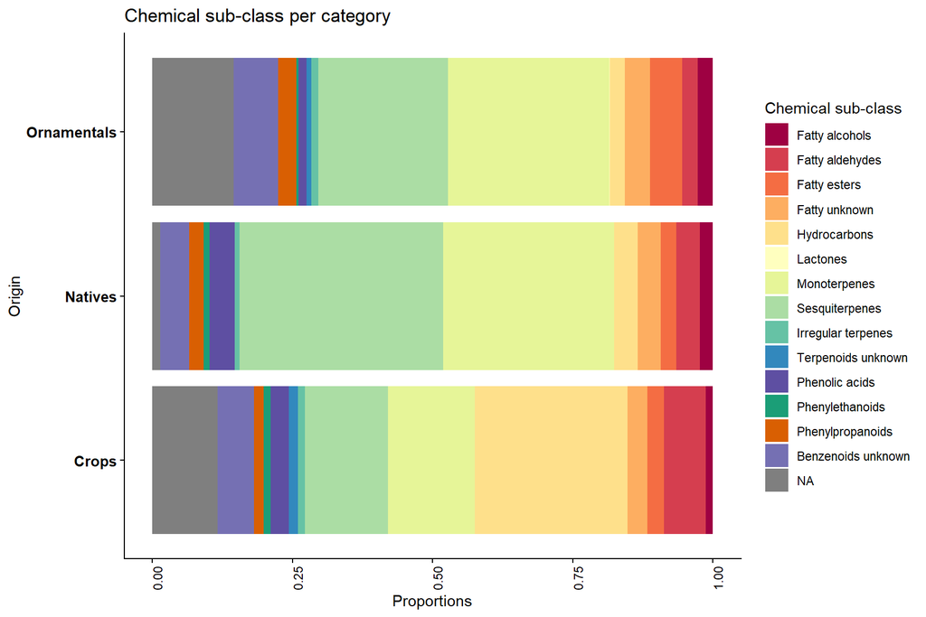

### ESM4

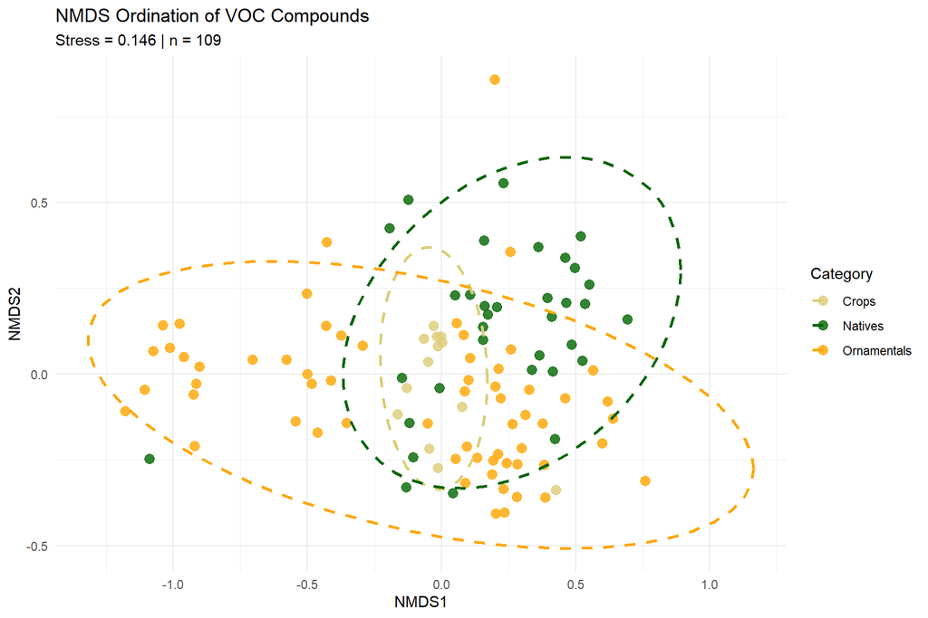

**ESM4: PERMANOVA (Bray–Curtis, category)**

```
Permutation test for adonis under reduced model
Permutation: free
Number of permutations: 999

adonis2(formula = df_compounds ~ new_cat, data = df_wide, method = "bray", na.action = na.fail)
          Df SumOfSqs      R2      F Pr(>F)
Model      2    3.473 0.07144 4.0776  0.001 ***
Residual 106   45.146 0.92856
Total    108   48.619 1.00000
---
Signif. codes:  0 '***' 0.001 '**' 0.01 '*' 0.05 '.' 0.1 ' ' 1
```

### ESM5

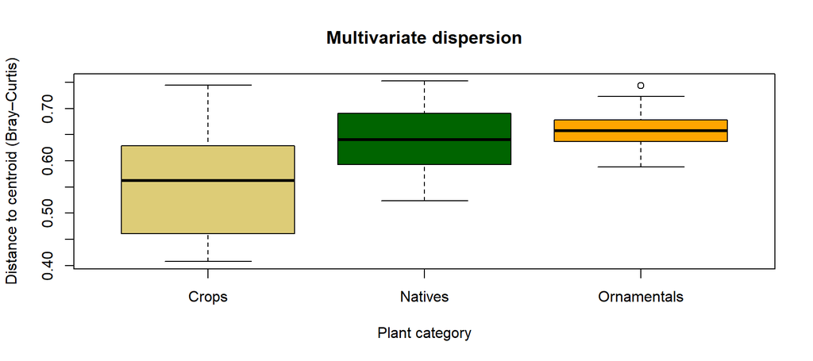

**ESM5: Dispersion (anova/permutest) and ANOVA (richness, Shannon)**

|  | Df | Sum Sq | Mean Sq | F value | Pr(>F) |
| --- | --- | --- | --- | --- | --- |
| Groups | 2 | 0.1104369 | 0.055218459 | 17.32291 | 3.093782e-07 |
| Residuals | 106 | 0.3378854 | 0.003187598 | NA | NA |

```
Permutation test for homogeneity of multivariate dispersions
Permutation: free
Number of permutations: 999

Response: Distances
           Df  Sum Sq  Mean Sq      F N.Perm Pr(>F)
Groups      2 0.11044 0.055218 17.323    999  0.001 ***
Residuals 106 0.33789 0.003188
---
Signif. codes:  0 '***' 0.001 '**' 0.01 '*' 0.05 '.' 0.1 ' ' 1
```

```
             Df Sum Sq Mean Sq F value   Pr(>F)
new_cat       2   7165    3583   21.37 1.59e-08 ***
Residuals   106  17769     168
---
Signif. codes:  0 '***' 0.001 '**' 0.01 '*' 0.05 '.' 0.1 ' ' 1
```

```
             Df Sum Sq Mean Sq F value   Pr(>F)
new_cat       2  17.87   8.936   13.74 4.96e-06 ***
Residuals   106  68.96   0.651
---
Signif. codes:  0 '***' 0.001 '**' 0.01 '*' 0.05 '.' 0.1 ' ' 1
```

### ESM6

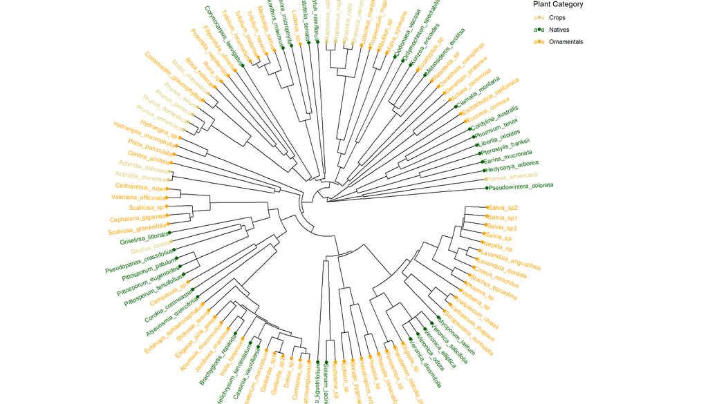

**ESM6: Pagel’s λ (phylogenetic signal in VOC richness)**

```
[1] "x has no names; assuming x is in the same order as tree$tip.label"
```

```
Phylogenetic signal lambda : 0.281416
logL(lambda) : -465.667
LR(lambda=0) : 1.95409
P-value (based on LR test) : 0.162147
```

**ESM6: PGLS (VOC richness ~ 1 and ~ new_cat)**

```
Call:
caper::pgls(formula = voc_richness ~ 1, data = comp_data, lambda = "ML")

Residuals:
    Min      1Q  Median      3Q     Max
-1.4366 -0.7930 -0.5089  0.3078  6.0886

Branch length transformations:

kappa  [Fix]  : 1.000
lambda [ ML]  : 0.281
   lower bound : 0.000, p = 0.16215
   upper bound : 1.000, p = 8.9589e-12
   95.0% CI   : (NA, 0.691)
delta  [Fix]  : 1.000

Coefficients:
            Estimate Std. Error t value  Pr(>|t|)
(Intercept)  14.7293     3.0407  4.8441 4.114e-06 ***
---
Signif. codes:  0 '***' 0.001 '**' 0.01 '*' 0.05 '.' 0.1 ' ' 1

Residual standard error: 1.342 on 112 degrees of freedom
Multiple R-squared:     0,  Adjusted R-squared:     0
F-statistic:   NaN on 0 and 112 DF,  p-value: NA
```

```
Call:
caper::pgls(formula = voc_richness ~ new_cat, data = comp_data,
    lambda = "ML")

Residuals:
    Min      1Q  Median      3Q     Max
-2.7845 -0.4952 -0.3103  0.1910  6.0239

Branch length transformations:

kappa  [Fix]  : 1.000
lambda [ ML]  : 0.000
   lower bound : 0.000, p = 1
   upper bound : 1.000, p = < 2.22e-16
   95.0% CI   : (NA, 0.135)
delta  [Fix]  : 1.000

Coefficients:
                   Estimate Std. Error t value  Pr(>|t|)
(Intercept)         36.4615     3.5596 10.2432 < 2.2e-16 ***
new_catNatives     -24.8439     4.1851 -5.9363 3.455e-08 ***
new_catOrnamentals -25.6888     3.8944 -6.5964 1.526e-09 ***
---
Signif. codes:  0 '***' 0.001 '**' 0.01 '*' 0.05 '.' 0.1 ' ' 1

Residual standard error: 1.101 on 110 degrees of freedom
Multiple R-squared: 0.2911, Adjusted R-squared: 0.2782
F-statistic: 22.58 on 2 and 110 DF,  p-value: 6.071e-09
```

**ESM6: Mantel test (VOC dissimilarity vs phylogenetic distance)**

```
Mantel statistic based on Pearson's product-moment correlation

Call:
mantel(xdis = voc_dist, ydis = phylo_dist, permutations = 999)

Mantel statistic r: 0.04747
      Significance: 0.031

Upper quantiles of permutations (null model):
   90%    95%  97.5%    99%
0.0321 0.0406 0.0508 0.0614
Permutation: free
Number of permutations: 999
```

### ESM7

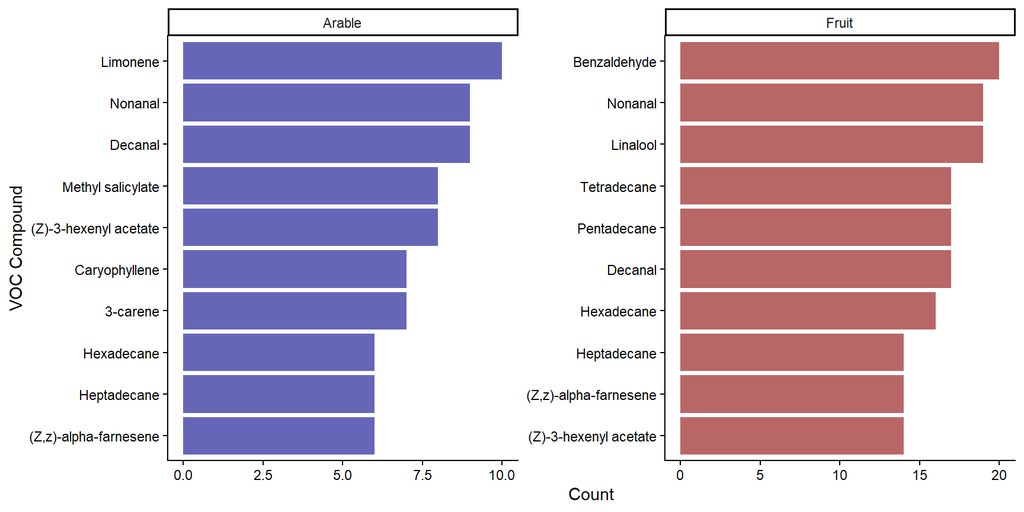

# References

R Core Team (2022). R: A language and environment for statistical computing. R Foundation for Statistical Computing, Vienna, Austria. https://www.R-project.org/